# Tutorial: Introduction to Modeling in Gen

Forked from probcomp, editted & simplified by Maddie Cusimano for 2020/03/11 McDermott Lab meeting

### Intro to Gen

Gen is a multi-paradigm platform for probabilistic modeling and inference. Gen supports multiple modeling and inference workflows, including:

- Unsupervised learning and posterior inference in generative models using Monte Carlo, variational, EM, and stochastic gradient techniques.
- Supervised learning of conditional inference models (e.g. supervised classification and regression).
- Hybrid approaches including amortized inference / inference compilation, variational autoencoders, and semi-supervised learning.

In Gen, probabilistic models (both generative models and conditional inference models) are represented as *generative functions*. Gen provides a built-in modeling language for defining generative functions. This tutorial introduces the basics of Gen's built-in modeling language, and illustrates a few types of modeling flexibility afforded by the language, including:

- Using a stochastic branching and function abstraction to express uncertainty about which of multiple models is appropriate (model structure).
- Representing models with an unbounded number of parameters (a 'Bayesian non-parametric' model).

### This notebook

This notebook uses a simple generic inference algorithm for posterior inference, and shows some examples of inference being applied to simple models. The notebook also introduces a technique for validating a model and inference algorithm by predicting new data from inferred parameters, and comparing this data to the observed data set.

This tutorial does not cover *custom inference programming*, which is a key capability of Gen in which users implement inference algorithms that are specialized to their probabilistic model. Inference programming is important for getting accurate posterior inferences efficiently, and we'll cover the basics of that next. Also, this tutorial does not exhaustively cover all features of the modeling language -- there are also features and extensions that provide improved performance that are not covered here.

## Outline

**Section 1.** Julia, Gen, and this Jupyter notebook

**Section 2.** Writing a probabilistic model as a generative function

**Section 3.** Doing posterior inference

**Section 4.** Predicting new data

**Section 5.** Calling other generative functions

**Section 6.** Modeling with an unbounded number of parameters

## 1. Julia, Gen, and this Jupyter notebook

Gen is a package for the Julia language. The package can be loaded with:

```julia
using Gen
```

Gen programs typically consist of a combination of (i) probabilistic models written in modeling languages and (ii) inference programs written in regular Julia code. Gen provides a built-in modeling language that is itself based on Julia.

This tutorial uses a Jupyter notebook. All cells in the notebook are regular Julia cells. In Julia, semicolons are optional at the end of statements; we will use them at the end of some cells so that the value of the cell is not printed.

```julia
a = 1 + 1
```

```
2
```

```julia
a = 1 + 1;
```

This notebook uses the [PyPlot](https://github.com/JuliaPy/PyPlot.jl) Julia package for plotting. PyPlot wraps the matplotlib Python package.

```julia
using PyPlot
```

This notebook will make use of Julia symbols. Note that a Julia symbol is different from a Julia string:

```julia
typeof(:foo)
```

```
Symbol
```

```julia
typeof("foo")
```

```
String
```

## 2. Writing a probabilistic model as a generative function

Probabilistic models are represented in Gen as *generative functions*. The simplest way to construct a generative function is by using the [built-in modeling Domain Specific Language (DSL)](https://probcomp.github.io/Gen/dev/ref/modeling/). Generative functions written in the built-in modeling DSL are based on Julia function definition syntax, but are prefixed with the `@gen` keyword. The function represents the data-generating process we are modeling: each random choice it makes can be thought of as a random variable in the model.

The generative function below represents a probabilistic model of a linear relationship in the x-y plane. Given a set of $x$ coordinates, it randomly chooses a line in the plane and generates corresponding $y$ coordinates so that each $(x, y)$ is near the line. We might think of this function as modeling house prices as a function of square footage, or the measured volume of a gas as a function of its measured temperature.

```julia
@gen function line_model(xs::Vector{Float64})
    n = length(xs)

    # We begin by sampling a slope and intercept for the line.
    # Before we have seen the data, we don't know the values of
    # these parameters, so we treat them as random choices. The
    # distributions they are drawn from represent our prior beliefs
    # about the parameters: in this case, that neither the slope nor the
    # intercept will be more than a couple points away from 0.
    slope = @trace(normal(0, 1), :slope)
    intercept = @trace(normal(0, 2), :intercept)

    # Given the slope and intercept, we can sample y coordinates
    # for each of the x coordinates in our input vector.
    # Each y coordinate is a noisy sample around the line defined by :slope and :intercept
    for (i, x) in enumerate(xs)
        @trace(normal(slope * x + intercept, 0.1), (:y, i))
    end

    # The return value of the model is often not particularly important,
    # Here, we simply return n, the number of points.
    return n
end;
```

The generative function takes as an argument a vector of x-coordinates. We create one below:

```julia
xs = [-5., -4., -3., -2., -1., 0., 1., 2., 3., 4., 5.];
```

Given this vector, the generative function samples a random choice representing the slope of a line from a normal distribution with mean 0 and standard deviation 1, and a random choice representing the intercept of a line from a normal distribution with mean 0 and standard deviation 2. In Bayesian statistics terms, these distributions are the *prior distributions* of the slope and intercept respectively. Then, the function samples values for the y-coordinates corresponding to each of the provided x-coordinates.

This generative function returns the number of data points. We can run the function like we run a regular Julia function:

```julia
n = line_model(xs)
println(n)
```

```
11
```

More interesting than `n` are the values of the random choices that `line_model` makes. **Crucially, each random choice is annotated with a unique *address*.** A random choice is assigned an address using the `@trace` keyword. Addresses can be any Julia value. In this program, there are two types of addresses used -- Julia symbols and tuples of symbols and integers. Note that within the `for` loop, the same line of code is executed multiple times, but each time, the random choice it makes is given a distinct address.

Although the random choices are not included in the return value, they *are* included in the *execution trace* of the generative function. We can run the generative function and obtain its trace using the [`simulate`](https://probcomp.github.io/Gen/dev/ref/gfi/#Gen.simulate) method from the Gen API:

```julia
trace = Gen.simulate(line_model, (xs,));
```

This method takes the function to be executed, and a tuple of arguments to the function, and returns a trace and a second value that we will not be using in this tutorial. When we print the trace, we see that it is a complex data structure.

```julia
println(trace)
```

```
Gen.DynamicDSLTrace{DynamicDSLFunction{Any}}(DynamicDSLFunction{Any}(Dict{Symbol,Any}(), Dict{Symbol,Any}(), Type[Array{Float64,1}], ##line_model#363, Bool[false], false), Trie{Any,Gen.ChoiceOrCallRecord}(Dict{Any,Gen.ChoiceOrCallRecord}((:y, 7)=>ChoiceOrCallRecord{Float64}(-1.67085, 1.35063, NaN, t…
```

A trace of a generative function contains various information about an execution of the function. For example, it contains the arguments on which the function was run, which are available with the API method `get_args`:

```julia
Gen.get_args(trace)
```

```
([-5.0, -4.0, -3.0, -2.0, -1.0, 0.0, 1.0, 2.0, 3.0, 4.0, 5.0],)
```

The trace also contains the value of the random choices, stored in map from address to value called a *choice map*. This map is available through the API method `get_choices`:

```julia
println(Gen.get_choices(trace))
```

```
│
├── (:y, 7) : -1.670848726202574
│
├── (:y, 9) : -2.9145647938991153
│
├── (:y, 1) : 2.717258401543057
│
├── (:y, 10) : -3.8353138857162103
│
├── (:y, 5) : -0.1747201254053448
│
├── (:y, 4) : 0.46563071295780983
│
├── :intercept : -0.8997894157398202
│
├── (:y, 3) : 1.2215841517099753
│
├── (:y, 6) : -0.740647759915393
│
├── (:y, 8) : -2.266852895450653
│
├── (:y, 11) : -4.706774413746015
│
├── (:y, 2) : 1.8854911154915
│
└── :slope : -0.7453626706881086
```

We can pull out individual values from this map using Julia's subscripting syntax `[...]`:

```julia
choices = Gen.get_choices(trace)
println(choices[:slope])
```

```
-0.7453626706881086
```

We can also read the value of a random choice directly from the trace, without having to use `get_choices` first:

```julia
println(trace[:slope])
```

```
-0.7453626706881086
```

The return value is also recorded in the trace, and is accessible with the `get_retval` API method:

```julia
println(Gen.get_retval(trace));
```

```
11
```

In order to understand the probabilistic behavior of a generative function, it is helpful to be able to visualize its traces. Below, we define a function that uses PyPlot to render a trace of the generative function above. The rendering shows the x-y data points and the line that is represented by the slope and intercept choices.

```julia
function render_trace(trace; show_data=true)

    # Pull out xs from the trace
    xs = get_args(trace)[1]

    xmin = minimum(xs)
    xmax = maximum(xs)
    if show_data
        ys = [trace[(:y, i)] for i=1:length(xs)]

        # Plot the data set
        scatter(xs, ys, c="black")
    end

    # Pull out slope and intercept from the trace
    slope = trace[:slope]
    intercept = trace[:intercept]

    # Draw the line
    plot([xmin, xmax], slope *  [xmin, xmax] .+ intercept, color="black", alpha=0.5)
    ax = gca()
    ax.set_xlim((xmin, xmax))
    ax.set_ylim((xmin, xmax))
end;
```

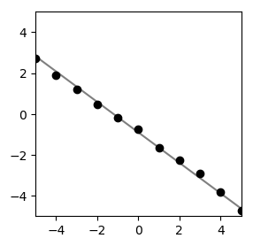

```julia
figure(figsize=(3,3))
render_trace(trace);
```

Because a generative function is stochastic, we need to visualize many runs in order to understand its behavior. The cell below renders a grid of traces.

```julia
function grid(renderer::Function, traces; ncols=6, nrows=3)
    figure(figsize=(16, 8))
    for (i, trace) in enumerate(traces)
        subplot(nrows, ncols, i)
        renderer(trace)
    end
end;
```

Now, we generate several traces and render them in a grid

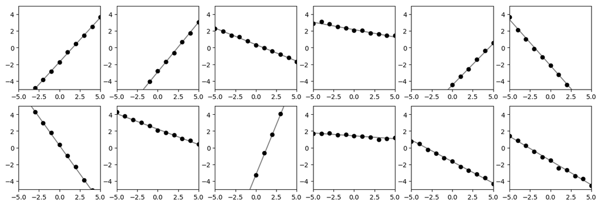

```julia
traces = [Gen.simulate(line_model, (xs,)) for _=1:12]
grid(render_trace, traces)
```

### Exercise

Write the generative function for the simple conjugate prior Gaussian model that we discussed (with a variable number of observations).

### Solution

```julia
@gen function simple_graphical_model(n::Int)

    # S ~ Normal(mu=0, sigma=1)
    # I_i ~ Normal(mu=S, sigma=1)

    S = @trace(normal(0,1),:S)
    for i = 1:n
        I_i = @trace(normal(S,1),(:I,i))
    end
    return S

end;
trace = Gen.simulate(simple_graphical_model,(3,))
println(get_choices(trace))
#TO DO: return the choices of the trace
```

```
│
├── (:I, 1) : 0.7630388458561772
│
├── (:I, 2) : 0.5097882950394912
│
├── :S : 0.2707267379692728
│
└── (:I, 3) : 0.2694270744526249
```

Edit this generative function so that it uses the same address more than once. Run it to see what happens.

```julia
@gen function buggy_graphical_model(n::Int)

    # S ~ Normal(mu=0, sigma=1)
    # I_i ~ Normal(mu=S, sigma=1)

    S = @trace(normal(0,1),:S)
    for i = 1:n
        I_i = @trace(normal(S,1),:I)
    end
    return S

end;
trace = Gen.simulate(buggy_graphical_model,(3,))
println(get_choices(trace))
#TO DO: return the choices of the trace
```

```
Attempted to visit address I, but it was already visited

Stacktrace:
 [1] error(::String) at ./error.jl:33
 [2] visit! at /Users/maddiecusimano/.julia/packages/Gen/8Rcd2/src/dynamic/dynamic.jl:107 [inlined]
 [3] traceat(::Gen.GFSimulateState, ::Gen.Normal, ::Tuple{Float64,Int64}, ::Symbol) at /Users/maddiecusimano/.julia/packages/Gen/8Rcd2/src/dynamic/simulate.jl:17
 [4] ##buggy_graphical_model#370(::Gen.GFSimulateState, ::Int64) at ./In[27]:8
 [5] exec(::DynamicDSLFunction{Any}, ::Gen.GFSimulateState, ::Tuple{Int64}) at /Users/maddiecusimano/.julia/packages/Gen/8Rcd2/src/dynamic/dynamic.jl:39
 [6] simulate(::DynamicDSLFunction{Any}, ::Tuple{Int64}) at /Users/maddiecusimano/.julia/packages/Gen/8Rcd2/src/dynamic/simulate.jl:61
 [7] top-level scope at In[27]:13
```

## 3. Doing Posterior inference

We now will provide a data set of y-coordinates and try to draw inferences about the process that generated the data. We begin with the following data set:

```julia
ys = [6.75003, 6.1568, 4.26414, 1.84894, 3.09686, 1.94026, 1.36411, -0.83959, -0.976, -1.93363, -2.91303];
```

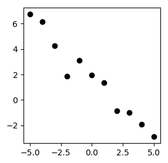

```julia
figure(figsize=(3,3))
scatter(xs, ys, color="black");
```

We will assume that the line model was responsible for generating the data, and infer values of the slope and intercept that explain the data.

To do this, we write a simple *inference program* that takes the model we are assuming generated our data, the data set, and the amount of computation to perform, and returns a trace of the function that is approximately sampled from the *posterior distribution* on traces of the function, given the observed data. That is, the inference program will try to find a trace that well explains the dataset we created above. We can inspect that trace to find estimates of the slope and intercept of a line that fits the data.

Functions like `importance_resampling` expect us to provide a *model* and also an *choice map* representing our data set and relating it to the model. A choice map maps random choice addresses from the model to values from our data set. Here, we want to tie model addresses like `(:y, 4)` to data set values like `ys[4]`:

```julia
function do_inference(model, xs, ys, amount_of_computation)

    # Create a choice map that maps model addresses (:y, i)
    # to observed values ys[i]. We leave :slope and :intercept
    # unconstrained, because we want them to be inferred.
    observations = Gen.choicemap()
    for (i, y) in enumerate(ys)
        observations[(:y, i)] = y
    end

    # Call importance_resampling to obtain a likely trace consistent
    # with our observations.
    (trace, _) = Gen.importance_resampling(model, (xs,), observations, amount_of_computation);
    return trace
end;
```

We can run the inference program to obtain a trace, and then visualize the result:

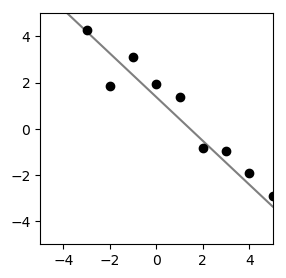

```julia
trace = do_inference(line_model, xs, ys, 100)
figure(figsize=(3,3))
render_trace(trace);
```

We see that `importance_resampling` found a reasonable slope and intercept to explain the data. We can also visualize many samples in a grid:

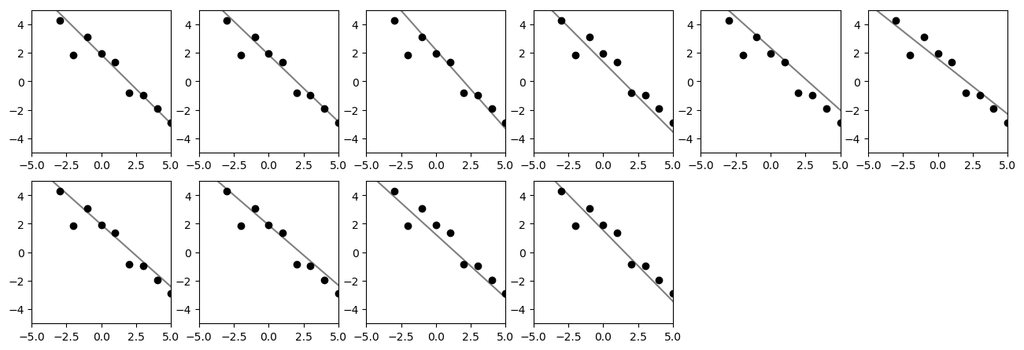

```julia
traces = [do_inference(line_model, xs, ys, 100) for _=1:10];
grid(render_trace, traces)
```

We can see here that there is some uncertainty: with our limited data, we can't be 100% sure exactly where the line is. We can get a better sense for the variability in the posterior distribution by visualizing all the traces in one plot, rather than in a grid. Each trace is going to have the same observed data points, so we only plot those once, based on the values in the first trace:

```julia
function overlay(renderer, traces; same_data=true, args...)
    renderer(traces[1], show_data=true, args...)
    for i=2:length(traces)
        renderer(traces[i], show_data=!same_data, args...)
    end
end;
```

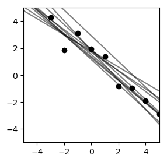

```julia
traces = [do_inference(line_model, xs, ys, 100) for _=1:10];
figure(figsize=(3,3))
overlay(render_trace, traces);
```

## 4. Predicting new data

Using the API method [`generate`](https://probcomp.github.io/Gen/dev/ref/gfi/#Gen.generate), we can generate a trace of a generative function in which the values of certain random choices are constrained to given values. The constraints are a choice map that maps the addresses of the constrained random choices to their desired values.

For example:

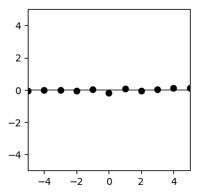

```julia
constraints = Gen.choicemap()
#note that this is a similar construct to "observations"
constraints[:slope] = 0.
constraints[:intercept] = 0.
(trace, _) = Gen.generate(line_model, (xs,), constraints)
figure(figsize=(3,3))
render_trace(trace);
```

Note that the random choices corresponding to the y-coordinates are still made randomly. Run the cell above a few times to verify this.

We will use the ability to run constrained executions of a generative function to predict the value of the y-coordinates at new x-coordinates by running new executions of the model generative function in which the random choices corresponding to the parameters have been constrained to their inferred values. We have provided a function below (`predict_new_data`) that takes a trace, and a vector of new x-coordinates, and returns a vector of predicted y-coordinates corresponding to the x-coordinates in `new_xs`. We have designed this function to work with multiple models, so the set of parameter addresses is an argument (`param_addrs`):

```julia
function predict_new_data(model, trace, new_xs::Vector{Float64}, param_addrs)

    # Copy parameter values from the inferred trace (`trace`)
    # into a fresh set of constraints.
    constraints = Gen.choicemap()
    for addr in param_addrs
        constraints[addr] = trace[addr]
    end

    # Run the model with new x coordinates, and with line parameters
    # fixed to be the inferred values
    (new_trace, _) = Gen.generate(model, (new_xs,), constraints)

    # Pull out the y-values and return them
    ys = [new_trace[(:y, i)] for i=1:length(new_xs)]
    return ys
end;
```

The cell below defines a function that first performs inference on an observed data set `(xs, ys)`, and then runs `predict_new_data` to generate predicted y-coordinates. It repeats this process `num_traces` times, and returns a vector of the resulting y-coordinate vectors.

```julia
function infer_and_predict(model, xs, ys, new_xs, param_addrs, num_traces, amount_of_computation)
    pred_ys = []
    #Make "num_traces" sets of predictions for based on the same (xs, ys) data
    for i=1:num_traces
        #In do_inference, fix (xs,ys) and infer (:line, :intercept)
        trace = do_inference(model, xs, ys, amount_of_computation)
        #In predict new data, fix (:line, :intercept), and generate ys for new_xs
        push!(pred_ys, predict_new_data(model, trace, new_xs, param_addrs))
    end
    pred_ys
end;
```

Finally, we define a cell that plots the observed data set `(xs, ys)` as red dots, and the predicted data as small black dots.

```julia
function plot_predictions(xs, ys, new_xs, pred_ys)
    scatter(xs, ys, color="red")
    for pred_ys_single in pred_ys
        scatter(new_xs, pred_ys_single, color="black", s=1, alpha=0.3)
    end
end;
```

Recall the original dataset for the line model. The x-coordinates span the interval -5 to 5.

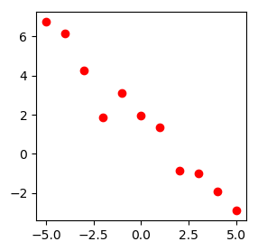

```julia
figure(figsize=(3,3))
scatter(xs, ys, color="red");
```

We will use the inferred values of the parameters to predict y-coordinates for x-coordinates in the interval 5 to 10 from which data was not observed. We will also predict new data within the interval -5 to 5, and we will compare this data to the original observed data. Predicting new data from inferred parameters, and comparing this new data to the observed data is the core idea behind *posterior predictive checking*. This tutorial does not intend to give a rigorous overview behind techniques for checking the quality of a model, but intends to give high-level intuition.

```julia
new_xs = collect(range(-5, stop=10, length=100));
```

We generate and plot the predicted data:

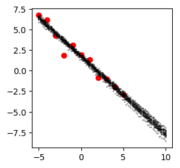

```julia
pred_ys = infer_and_predict(line_model, xs, ys, new_xs, [:slope, :intercept], 20, 1000)
figure(figsize=(3,3))
plot_predictions(xs, ys, new_xs, pred_ys)
```

The results look reasonable, both within the interval of observed data and in the extrapolated predictions on the right.

Now consider the same experiment run with following data set, which has significantly more noise.

```julia
ys_noisy = [5.092, 4.781, 2.46815, 1.23047, 0.903318, 1.11819, 2.10808, 1.09198, 0.0203789, -2.05068, 2.66031];
```

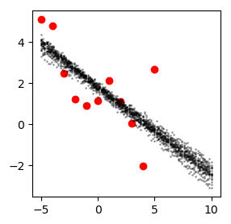

```julia
pred_ys = infer_and_predict(line_model, xs, ys_noisy, new_xs, [:slope, :intercept], 20, 1000)
figure(figsize=(3,3))
plot_predictions(xs, ys_noisy, new_xs, pred_ys)
```

It looks like the generated data is less noisy than the observed data in the regime where data was observed, and it looks like the forecasted data is too overconfident. This is a sign that our model is mis-specified. In our case, this is because we have assumed that the noise has value 0.1. However, the actual noise in the data appears to be much larger. We can correct this by making the noise a random choice as well and inferring its value along with the other parameters.

### Exercise

Write a new version of the line model that samples a random choice for the noise from a `gamma(1, 1)` prior distribution.

```julia
@gen function line_model_2(xs::Vector{Float64})
    n = length(xs)
    slope = @trace(normal(0, 1), :slope)
    intercept = @trace(normal(0, 2), :intercept)
    noise = @trace(gamma(1,1),:noise)
    # TO DO
    for (i, x) in enumerate(xs)
        @trace(normal(slope * x + intercept, noise), (:y, i))
    end
    return nothing
end;
```

Then, we compare the predictions using inference the unmodified and modified model on the `ys` data set:

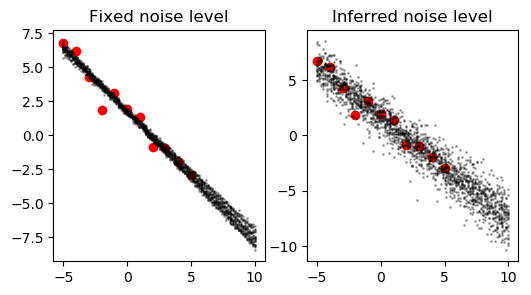

```julia
figure(figsize=(6,3))

pred_ys = infer_and_predict(line_model, xs, ys, new_xs, [:slope, :intercept], 20, 1000)
subplot(1, 2, 1)
title("Fixed noise level")
plot_predictions(xs, ys, new_xs, pred_ys)

pred_ys = infer_and_predict(line_model_2, xs, ys, new_xs, [:slope, :intercept, :noise], 20, 10000)
subplot(1, 2, 2)
title("Inferred noise level")
plot_predictions(xs, ys, new_xs, pred_ys)
```

Notice that there is more uncertainty in the predictions made using the modified model.

We also compare the predictions using inference the unmodified and modified model on the `ys_noisy` data set:

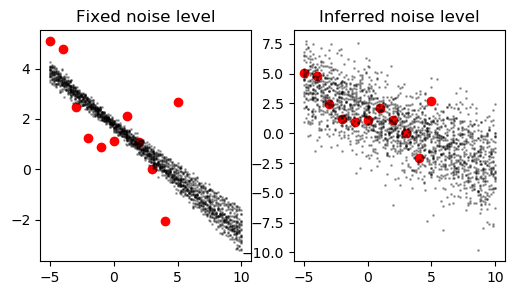

```julia
figure(figsize=(6,3))

pred_ys = infer_and_predict(line_model, xs, ys_noisy, new_xs, [:slope, :intercept], 20, 1000)
subplot(1, 2, 1)
title("Fixed noise level")
plot_predictions(xs, ys_noisy, new_xs, pred_ys)

pred_ys = infer_and_predict(line_model_2, xs, ys_noisy, new_xs, [:slope, :intercept, :noise], 20, 10000)
subplot(1, 2, 2)
title("Inferred noise level")
plot_predictions(xs, ys_noisy, new_xs, pred_ys)
```

Notice that while the unmodified model was very overconfident, the modified model has an appropriate level of uncertainty, while still capturing the general negative trend.

## 5. Calling other generative functions

In addition to making random choices, generative functions can invoke other generative functions. To illustrate this, we will write a probabilistic model that combines the line model and the sine model. This model is able to explain data using either model, and which model is chosen will depend on the data. This is called *model selection*.

A generative function can invoke another generative function in three ways:

- using regular Julia function call syntax
- using the `@trace` Gen keyword with an address: `@trace(<call>, <addr>)`
- using the `@trace` Gen keyword without an address: `@trace(<call>)`

When invoking using regular function call syntax, the random choices made by the callee function are not traced. When invoking using `@trace` without an address, the random choices of the callee function are placed in the same address namespace as the caller's random choices. When using `@trace(<call>, <addr>)`, the random choices of the callee are placed under the namespace `<addr>`.

```julia
@gen function foo()
    @trace(normal(0, 1), :y)
end

@gen function bar()
    @trace(bernoulli(0.5), :x)
    @trace(foo())
end

@gen function bar_using_namespace()
    @trace(bernoulli(0.5), :x)
    @trace(foo(), :z)
end;
```

We first show the addresses sampled by `bar`:

```julia
trace = Gen.simulate(bar, ())
println(Gen.get_choices(trace))
```

```
│
├── :y : 0.7897764896470524
│
└── :x : true
```

And the addresses sampled by `bar_using_namespace`:

```julia
trace = Gen.simulate(bar_using_namespace, ())
println(Gen.get_choices(trace))
```

```
│
├── :x : true
│
└── :z
    │
    └── :y : 1.2412542165474343
```

Using `@trace` with a namespace can help avoid address collisions for complex models.

A hierarchical address is represented as a Julia `Pair`, where the first element of the pair is the first element of the address and the second element of the pair is the rest of the address. A shorthand for the `Pair` constructor (eg `trace[Pair(:z, :y)]`) is `=>`, so we can access choices at hierarchical addresses like:

```julia
trace[:z => :y]
```

```
1.2412542165474343
```

If we have a hierarchical address with more than two elements, we can construct the address by chaining the `=>` operator:

```julia
@gen function baz()
    @trace(bar_using_namespace(), :a)
end

trace = simulate(baz, ())

trace[:a => :z => :y]
```

```
-1.1341265821366524
```

### Exercise

Let's write another model, where data is sampled from a noisy sine function.

Write a model that generates a sine wave with random phase, period and amplitude, and then generates y-coordinates from a given vector of x-coordinates by adding noise to the value of the wave at each x-coordinate. Use the following prior distributions:

- Period: gamma(5, 1)
- Amplitude: gamma(1, 1)
- Phase: uniform distribution
- Noise: gamma(1,1)

```julia
@gen function sine_model(xs::Vector{Float64})
    n = length(xs)

    period = @trace(gamma(5,1),:period)
    amplitude = @trace(gamma(1,1),:amplitude)
    phase = @trace(uniform(0,2*pi),:phase)
    noise = @trace(gamma(1,1),:noise)

    for (i, x) in enumerate(xs)
        @trace(normal(amplitude*sin(2*pi*x/period + phase), noise), (:y, i)) # < edit this line >
    end
    return n
end;
```

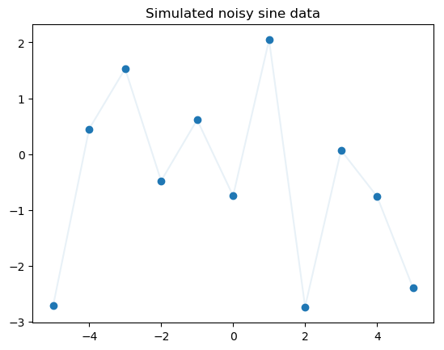

```
PyObject Text(0.5, 1.0, 'Simulated noisy sine data')
```

```julia
trace = simulate(sine_model,(xs,))
simulated_ys = [trace[(:y,i)] for i = 1:length(xs)]
plot(xs, simulated_ys,alpha=0.1);scatter(xs, simulated_ys)
title("Simulated noisy sine data")
```

Now, we write a generative function that combines the line and sine models. It makes a Bernoulli random choice (e.g. a coin flip that returns true or false) that determines which of the two models will generate the data.

```julia
@gen function combined_model(xs::Vector{Float64})
    if @trace(bernoulli(0.5), :is_line)
        @trace(line_model_2(xs))
    else
        @trace(sine_model(xs))
    end
end;
```

Let's write visualization for a trace of this function:

```julia
function render_combined(trace; show_data=true)
    xs = Gen.get_args(trace)[1]
    xmin = minimum(xs)
    xmax = maximum(xs)
    if show_data
        ys = [trace[(:y, i)] for i=1:length(xs)]
        scatter(xs, ys, c="black")
    end

    # < your code here >

    #= Old Code for Linear Model:
    # Pull out slope and intercept from the trace
    slope = trace[:slope]
    intercept = trace[:intercept]

    # Draw the line
    plot([xmin, xmax], slope *  [xmin, xmax] .+ intercept, color="black", alpha=0.5)
    ax = gca()
    ax.set_xlim((xmin, xmax))
    ax.set_ylim((xmin, xmax))
    =#

    if trace[:is_line]
        slope = trace[:slope]
        intercept = trace[:intercept]

        # Draw the line
        plot([xmin, xmax], slope *  [xmin, xmax] .+ intercept, color="black", alpha=0.5)
        ax = gca()
        ax.set_xlim((xmin, xmax))
        ax.set_ylim((xmin, xmax))
    else
        amplitude = trace[:amplitude]
        period = trace[:period]
        phase = trace[:phase]

        # Draw the line
        plot(xmin:0.01:xmax, amplitude*sin.(2*pi*(xmin:0.01:xmax)/period .+ phase) , color="black", alpha=0.5)
        ax = gca()
        ax.set_xlim((xmin, xmax))
        ax.set_ylim((xmin, xmax))
    end

    ax = gca()
    ax.set_xlim((xmin, xmax))
    ax.set_ylim((xmin, xmax))
end;
```

```julia
trace = Gen.simulate(combined_model, (xs,))
println(get_choices(trace))
#What would it look like if we gave @trace(line_model) and @trace(sin_model) addresses?
```

```
│
├── (:y, 7) : 0.2648921787198135
│
├── (:y, 9) : 2.2333469140003146
│
├── (:y, 1) : -3.077574118351368
│
├── (:y, 10) : 0.6918981853870032
│
├── (:y, 5) : 0.1210883430703037
│
├── (:y, 4) : 0.21586511710936618
│
├── :intercept : -0.13163409985870597
│
├── (:y, 3) : -1.9132483900134691
│
├── (:y, 6) : 0.704552001956272
│
├── (:y, 8) : 0.3051328101252615
│
├── (:y, 11) : 2.289183838841973
│
├── :noise : 0.7848427077696257
│
├── (:y, 2) : -1.8657164673651405
│
├── :slope : 0.49621040261561056
│
└── :is_line : true
```

We visualize some traces, and see that sometimes it samples linear data and other times sinusoidal data.

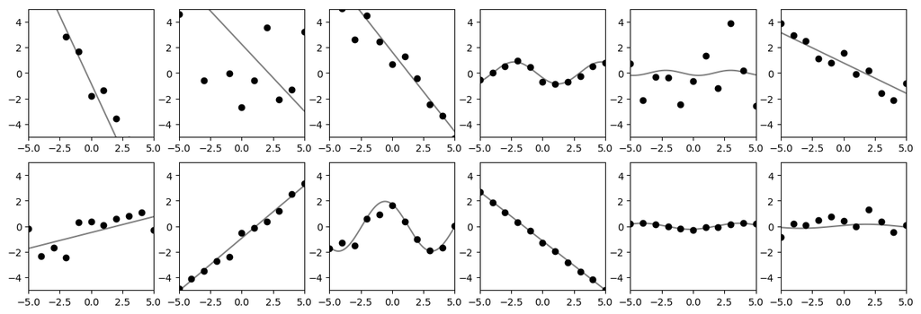

```julia
traces = [Gen.simulate(combined_model, (xs,)) for _=1:12];
grid(render_combined, traces)
```

We run inference using this combined model on the `ys` data set and a new `ys_sine` data set.

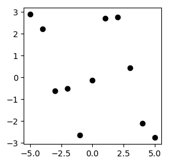

```julia
ys_sine = [2.89, 2.22, -0.612, -0.522, -2.65, -0.133, 2.70, 2.77, 0.425, -2.11, -2.76];
figure(figsize=(3, 3));
scatter(xs, ys_sine, color="black");
```

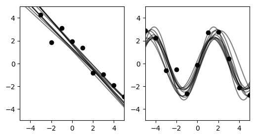

```julia
figure(figsize=(6,3))
subplot(1, 2, 1)
traces = [do_inference(combined_model, xs, ys, 10000) for _=1:10];
overlay(render_combined, traces)
subplot(1, 2, 2)
traces = [do_inference(combined_model, xs, ys_sine, 10000) for _=1:10];
overlay(render_combined, traces)
```

The results should show that the line model was inferred for the `ys` data set, and the sine wave model was inferred for the `ys_sine` data set.

## 6. Modeling with an unbounded number of parameters (skipping this section!)

Gen's built-in modeling language can be used to express models that use an unbounded number of parameters. This section walks you through development of a model of data that does not a-priori specify an upper bound on the complexity of the model, but instead infers the complexity of the model as well as the parameters. This is a simple example of a *Bayesian nonparametric* model.

Check the original gen-quickstart tutorial where they consider two data sets:

```julia
xs_dense = collect(range(-5, stop=5, length=50))
ys_simple = fill(1., length(xs_dense)) .+ randn(length(xs_dense)) * 0.1
ys_complex = [Int(floor(abs(x/3))) % 2 == 0 ? 2 : 0 for x in xs_dense] .+ randn(length(xs_dense)) * 0.1;
```

```julia
figure(figsize=(6,3))

subplot(1, 2, 1)
title("ys-simple")
scatter(xs_dense, ys_simple, color="black", s=10)
gca().set_ylim((-1, 3))

subplot(1, 2, 2)
title("ys-complex")
scatter(xs_dense, ys_complex, color="black", s=10)
gca().set_ylim((-1, 3))
```

[output not shown]